# Case Study

Aniketh V, Kenneth P

3/5/2020

# Beers and Breweries - Budweiser

## Introduction:

Greetings! Today we will be discussing “Beers and Breweries” within the United States. We will be covering what we can infer about the data points at hand as well as interesting key topics that you might find valuable for the business. We were able to develop some code to analyze this data. Please be advised that R was used to write the code for statistics and to visualize the data. At the end of this document, you will leave with sustainable information.

## Lets set up our environment

```r
#Load required libraries
library(ggplot2)
library(dplyr)
library(tidyr)
library(stringr)
library(magrittr)
library(maps)
library(mapproj)
library(maptools)
library(GGally)
library(ggalt)
library(mice)
library(e1071)
library(class)
library(caret)
#Import the data
beers = read.csv("/Users/password1234/Documents/Doing_Data_Science/MSDS_6306_Doing-Data-Science/Unit\ 8\ and\ 9\ Case\ Study\ 1/Beers.csv", header = TRUE)
breweries = read.csv("/Users/password1234/Documents/Doing_Data_Science/MSDS_6306_Doing-Data-Science/Unit\ 8\ and\ 9\ Case\ Study\ 1/Breweries.csv", header = TRUE)
```

## Part 1: How many breweries are present in each state?

The purpose of this block is to find out how many breweries are present per each state. To that we need to utilize the breweries file to obtain and visually produce this information.

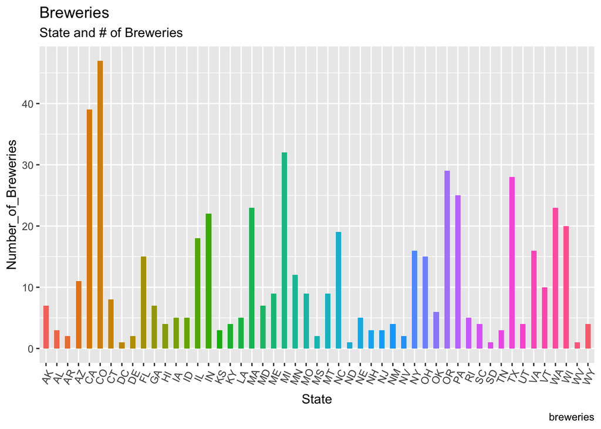

```r
#Lets first create a new data frame that only includes the number of breweries per state.
breweriesMapData = count(breweries, State)
#The count column was produced as a random variable, need to change that to a name thats more clean
colnames(breweriesMapData)[2] = "Number_of_Breweries"
#Lets visualize the data in a nice bar chart
breweriesMapData %>% ggplot(aes(x = State, y = Number_of_Breweries, fill = State)) + geom_bar(stat = "identity", width = .5) +
  labs(title = "Breweries", subtitle = "State and # of Breweries", caption = "breweries") + theme(axis.text.x = element_text(angle = 65, vjust = 0.6), legend.position = "none")
```

## Part 2: Lets Merge both data sets together

In order to get the best out of this evaluation, we will need to merge both the datasets together so it can be presentable. The datasets were joined by an indicator, in this case the common indicator is “Brew_ID”.

```r
#Need to change the column name for Breweries ID to a common name.
colnames(beers)[5] = "Brew_ID"

#Combining to one dataset called beersAndBrew
beersAndBrew = full_join(beers, breweries, by = "Brew_ID")
colnames(beersAndBrew)[1] = "Beer_Name"
colnames(beersAndBrew)[8] = "Brewery_Name"

#Print the first 6 observations
head(beersAndBrew, 6)
```

```
##             Beer_Name Beer_ID   ABV IBU Brew_ID
## 1            Pub Beer    1436 0.050  NA     409
## 2         Devil's Cup    2265 0.066  NA     178
## 3 Rise of the Phoenix    2264 0.071  NA     178
## 4            Sinister    2263 0.090  NA     178
## 5       Sex and Candy    2262 0.075  NA     178
## 6        Black Exodus    2261 0.077  NA     178
##                            Style Ounces              Brewery_Name City
## 1            American Pale Lager     12 10 Barrel Brewing Company Bend
## 2        American Pale Ale (APA)     12       18th Street Brewery Gary
## 3                   American IPA     12       18th Street Brewery Gary
## 4 American Double / Imperial IPA     12       18th Street Brewery Gary
## 5                   American IPA     12       18th Street Brewery Gary
## 6                  Oatmeal Stout     12       18th Street Brewery Gary
##   State
## 1    OR
## 2    IN
## 3    IN
## 4    IN
## 5    IN
## 6    IN
```

```r
#Print the last 6 Observations
tail(beersAndBrew, 6)
```

```
##                        Beer_Name Beer_ID   ABV IBU Brew_ID
## 2405 Rocky Mountain Oyster Stout    1035 0.075  NA     425
## 2406                   Belgorado     928 0.067  45     425
## 2407               Rail Yard Ale     807 0.052  NA     425
## 2408             B3K Black Lager     620 0.055  NA     425
## 2409         Silverback Pale Ale     145 0.055  40     425
## 2410        Rail Yard Ale (2009)      84 0.052  NA     425
##                         Style Ounces            Brewery_Name   City State
## 2405           American Stout     12 Wynkoop Brewing Company Denver    CO
## 2406              Belgian IPA     12 Wynkoop Brewing Company Denver    CO
## 2407 American Amber / Red Ale     12 Wynkoop Brewing Company Denver    CO
## 2408              Schwarzbier     12 Wynkoop Brewing Company Denver    CO
## 2409  American Pale Ale (APA)     12 Wynkoop Brewing Company Denver    CO
## 2410 American Amber / Red Ale     12 Wynkoop Brewing Company Denver    CO
```

## Part 3: What to do with missing data?

Missing data can be cumbersome, what we did to replace the missing values is use the mice function which computes the mean/median/mode of the columns at hand. This is handy as it evaluates the data based on similar observations and replace the missing values with the closest match (mean, median, or mode).

```r
#Need to create a new data frame with just ABV and IBU for faster compute time
ABVandIBU = beersAndBrew %>% select(ABV, IBU)

#Wrapper on MICE function which makes the response time for the function much faster. Adds an extra argument called droplist, where you can pass a character vector of predictor variables that you do not want used in the right-hand-side of the imputation formulas
ImputeData = function(data, m = 10, maxit = 15, droplist = NULL)
{
  if(length(intersect(names(data), droplist)) < length(droplist))
  {
    stop("Droplist variables not found in data set")
  }
  predictorMatrix = (1 - diag(1,ncol(data)))
  for (term in droplist)
  {
    drop.index = which(names(data) == term)
      predictorMatrix[, drop.index] = 0
  }
  mids.out = mice(data, m = m, maxit = maxit, predictorMatrix = predictorMatrix)
  return(mids.out)
}

imp = ImputeData(ABVandIBU, m = 1, maxit = 10)
ABVandIBU = complete(imp)

beersAndBrew = cbind(beersAndBrew, ABVandIBU)
#Rename to delete columns
colnames(beersAndBrew)[3] = "a"
colnames(beersAndBrew)[4] = "b"
beersAndBrew = select(beersAndBrew, -c(3:4))
#Reorder data
beersAndBrew = beersAndBrew[c(1,2,9,10,3,4,5,6,7,8)]
```

## Part 4: Computing the median alcohol content and international bitterness for each state

We want to see what the median ABV and IBU (Bitterness) for each state. To do this we need to summarise the data and be able to present in a bar graph format.In the bar charts we can see the frequency per state for the medians per the levels (ABV, IBU).

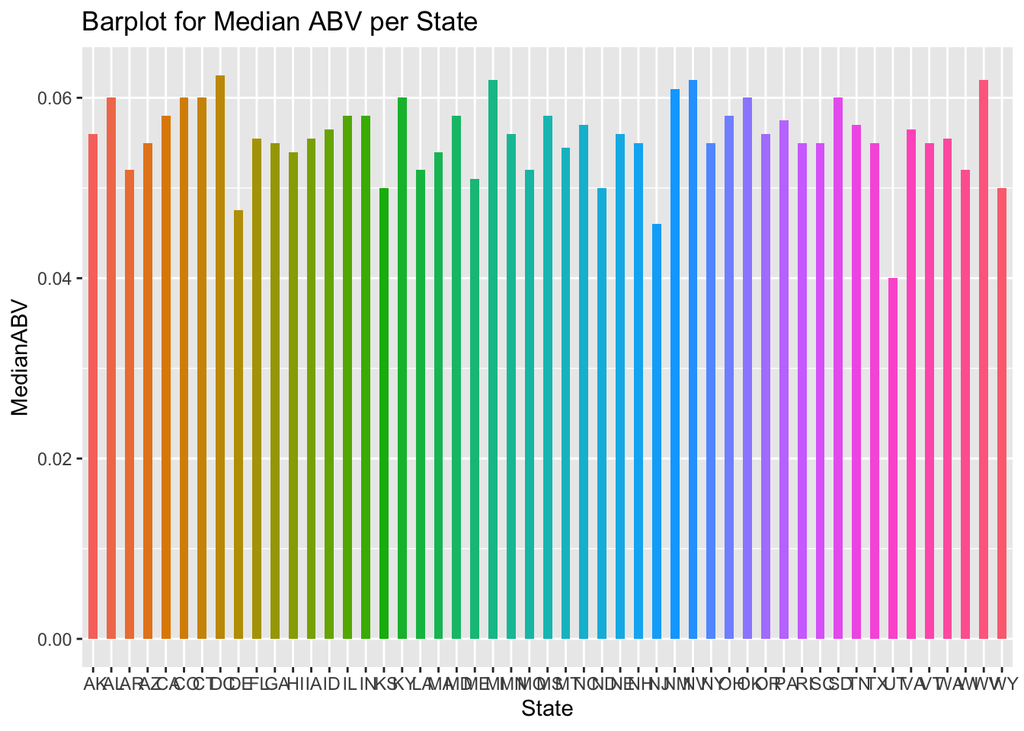

```r
#Select the data points needed and create a new data frame, in this case by median
byState = beersAndBrew %>% select(ABV, IBU, State) %>% group_by(State) %>% summarise(MedianABV = median(ABV), MedianIBU = median(IBU))

#Plot the data frame for ABV
byState %>% ggplot(aes(x = State, y = MedianABV, fill = State)) + geom_bar(stat = "identity", width = .5) + theme(legend.position = "none") + ggtitle("Barplot for Median ABV per State")
```

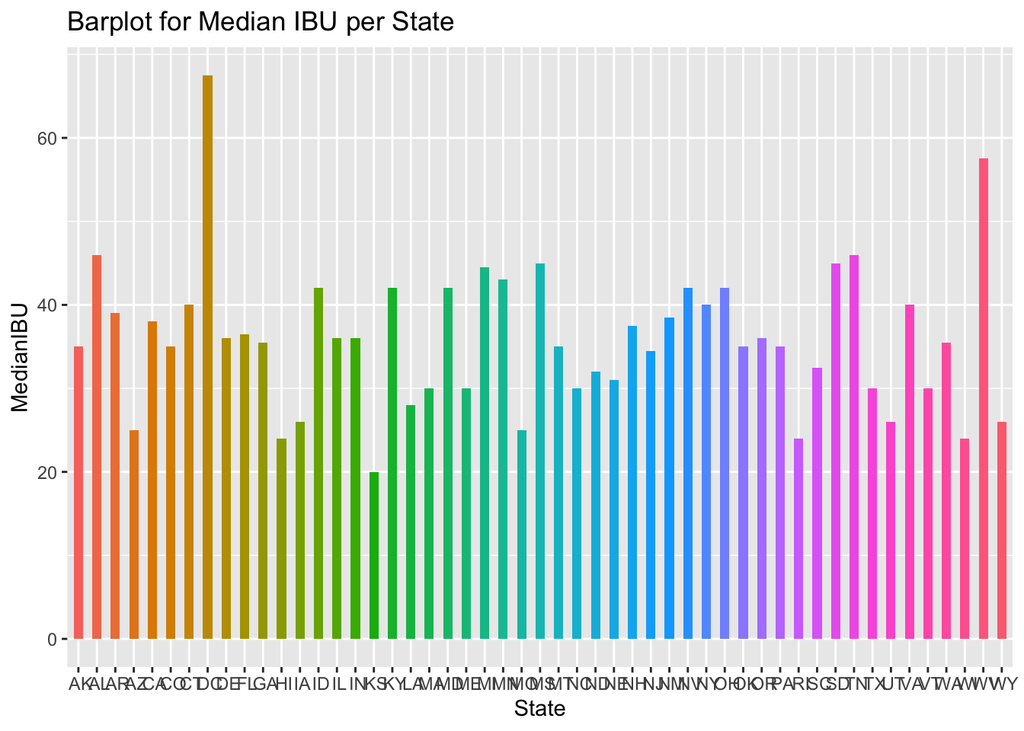

```r
#Plot the data frame for IBU
byState %>% ggplot(aes(x = State, y = MedianIBU, fill = State)) + geom_bar(stat = "identity", width = .5) + theme(legend.position = "none") + ggtitle("Barplot for Median IBU per State")
```

```r
#Finding the highest value for IBU and then tracing the state
max(beersAndBrew$IBU)
```

```
## [1] 138
```

```r
#Filter the State by above value
beersAndBrew %>% select(State, IBU) %>% filter(IBU == 138)
```

```
##   State IBU
## 1    OR 138
## 2    VT 138
```

```r
#Finding the highest value for ABV and then tracing the state
max(beersAndBrew$ABV)
```

```
## [1] 0.128
```

```r
#Filter the state with above value
beersAndBrew %>% select(State, ABV) %>% filter(ABV == 0.128)
```

```
##   State   ABV
## 1    CO 0.128
```

#Part 6: Summary statistics for ABV Figuring out the distribution and the statistics for alcohol content is also key. Especially when drinking beer, the higher the alcohol content the more the effects are felt. It is an important characteristic of a beer. Let dwelve into this variable.

As per the below histogram and summary we can see the the distribution is skewed slightly to the right but not signifcantly. This tells us the mean is larger than the median ever so slightly. In response to all the beers we can see that the majority of the beers hover around .04 to .065.

```r
#Lets get the summary
summary(beersAndBrew$ABV)
```

```
##    Min. 1st Qu.  Median    Mean 3rd Qu.    Max.
##  0.0010  0.0500  0.0560  0.0597  0.0670  0.1280
```

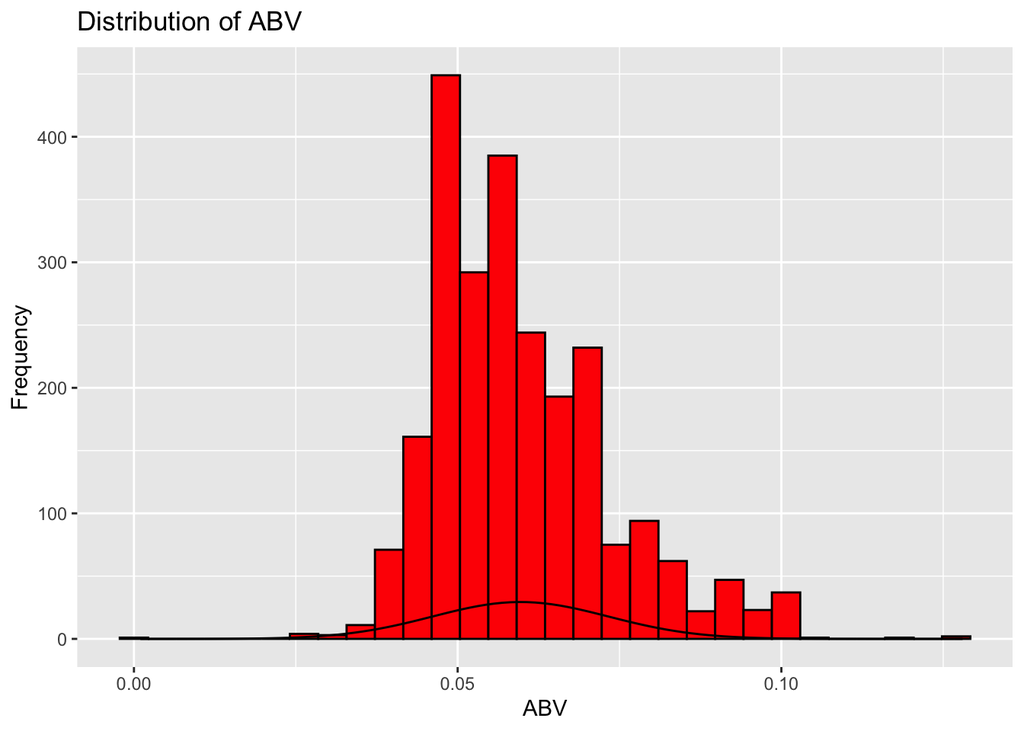

```r
#Lets find the distribution
beersAndBrew %>% ggplot(aes(x = ABV)) + geom_histogram(fill = "red", color = "black") + stat_function(fun = dnorm, args = list(mean = mean(beersAndBrew$ABV), sd = sd(beersAndBrew$ABV))) + ggtitle("Distribution of ABV") + ylab("Frequency")
```

## Part 7: Relationship between ABV and IBU

Is there any relationship between ABV and IBU? This is something the below code chunk can help address. An assumption that can be made is that as ABV rises so does bitterness and vice versa. In real world scenarios, its better not to assume.

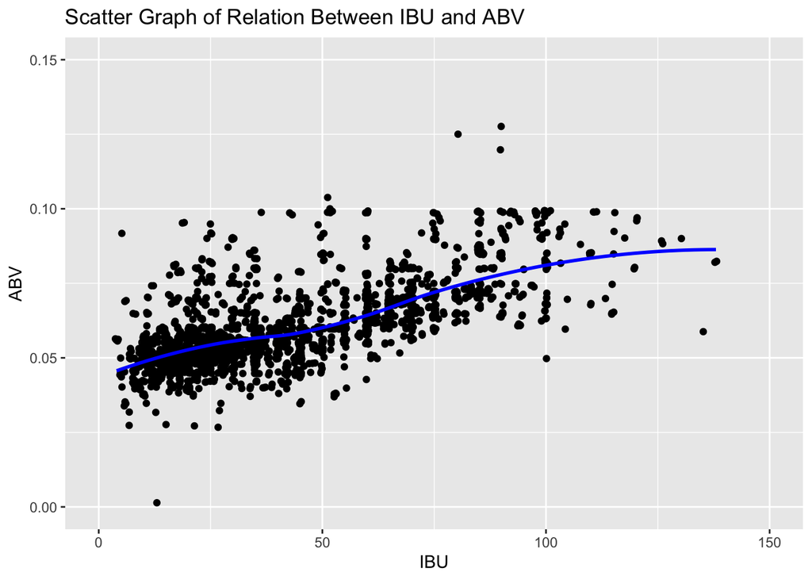

```r
#Scatter Graph
beersAndBrew %>% ggplot(aes(x = IBU, y = ABV)) + geom_point(position = "jitter") + geom_smooth(method = "loess", se=F, color = "blue") +
  xlim(c(0, 150)) + ylim(c(0, .15)) + ggtitle("Scatter Graph of Relation Between IBU and ABV")
```

## Part 8: K-NN in respects to ABV and IBU based on type of beer

One of the few takeaways for this presentation is to investigate the difference between IPA’s and Ale’s based on ABV and IBU. If we feed the training set with a beer with both ABV and IBU will it correctly classify the beer type? For the most part it does. If you feed the model specific values then the KNN algorithm correctly classify the right type based on its nearest neigbor.

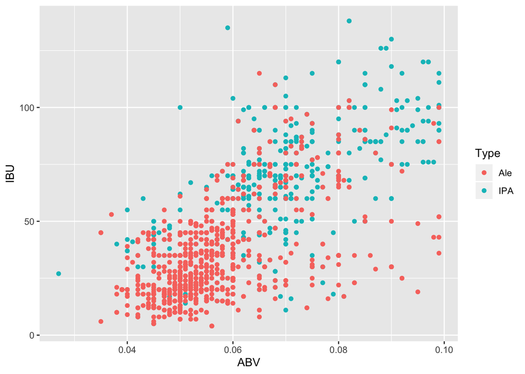

```r
#Split data to two sets that classify IPA and Ales
IPABeers = beersAndBrew %>% select(Beer_Name, ABV, IBU, Style) %>% filter(str_detect(Style, "IPA"))
AleBeers = beersAndBrew %>% select(Beer_Name, ABV, IBU, Style) %>% filter(str_detect(Style, "Ale"))
#Create new column for type
IPABeers$Type = "IPA"
AleBeers$Type = "Ale"

#Combine into one for KNN classification
beersALEIPA = rbind(IPABeers, AleBeers)
#plot
beersALEIPA %>% ggplot(aes(x = ABV, y = IBU, color = Type)) + geom_point()
```

```r
#Start KNN inital test by feeding a random ABV and IBU
beerTest = data.frame(ABV = 0.05, IBU = 45)
knn(beersALEIPA[,2:3], beerTest, beersALEIPA$Type, k = 7, prob = TRUE)
```

```
## [1] Ale
## attr(,"prob")
## [1] 0.8571429
## Levels: Ale IPA
```

```r
#Train data set and test data set, evaluate with both
set.seed(6)
splitPerc = .70
trainIndices = sample(1:dim(beersALEIPA)[1], round(splitPerc * dim(beersALEIPA)[1]))
train = beersALEIPA[trainIndices,]
test = beersALEIPA[-trainIndices,]

# k = 3
classifications = knn(train[, c(2,3)], test[, c(2,3)], train$Type, prob = TRUE, k = 3)
table(classifications, test$Type)
```

```
##
## classifications Ale IPA
##             Ale 262  59
##             IPA  44  99
```

```r
confusionMatrix(table(classifications, test$Type))
```

```
## Confusion Matrix and Statistics
##
##
## classifications Ale IPA
##             Ale 262  59
##             IPA  44  99
##
##                Accuracy : 0.778
##                  95% CI : (0.7374, 0.815)
##     No Information Rate : 0.6595
##     P-Value [Acc > NIR] : 1.636e-08
##
##                   Kappa : 0.4941
##
##  Mcnemar's Test P-Value : 0.1678
##
##             Sensitivity : 0.8562
##             Specificity : 0.6266
##          Pos Pred Value : 0.8162
##          Neg Pred Value : 0.6923
##              Prevalence : 0.6595
##          Detection Rate : 0.5647
##    Detection Prevalence : 0.6918
##       Balanced Accuracy : 0.7414
##
##        'Positive' Class : Ale
##
```

```r
# k = 7
classifications = knn(train[, c(2,3)], test[, c(2,3)], train$Type, prob = TRUE, k = 7)
table(classifications, test$Type)
```

```
##
## classifications Ale IPA
##             Ale 262  52
##             IPA  44 106
```

```r
confusionMatrix(table(classifications, test$Type))
```

```
## Confusion Matrix and Statistics
##
##
## classifications Ale IPA
##             Ale 262  52
##             IPA  44 106
##
##                Accuracy : 0.7931
##                  95% CI : (0.7534, 0.8291)
##     No Information Rate : 0.6595
##     P-Value [Acc > NIR] : 1.758e-10
##
##                   Kappa : 0.5336
##
##  Mcnemar's Test P-Value : 0.475
##
##             Sensitivity : 0.8562
##             Specificity : 0.6709
##          Pos Pred Value : 0.8344
##          Neg Pred Value : 0.7067
##              Prevalence : 0.6595
##          Detection Rate : 0.5647
##    Detection Prevalence : 0.6767
##       Balanced Accuracy : 0.7635
##
##        'Positive' Class : Ale
##
```

```r
#k = 13
classifications = knn(train[, c(2,3)], test[, c(2,3)], train$Type, prob = TRUE, k = 13)
table(classifications, test$Type)
```

```
##
## classifications Ale IPA
##             Ale 269  56
##             IPA  37 102
```

```r
confusionMatrix(table(classifications, test$Type))
```

```
## Confusion Matrix and Statistics
##
##
## classifications Ale IPA
##             Ale 269  56
##             IPA  37 102
##
##                Accuracy : 0.7996
##                  95% CI : (0.7602, 0.8351)
##     No Information Rate : 0.6595
##     P-Value [Acc > NIR] : 2.083e-11
##
##                   Kappa : 0.5404
##
##  Mcnemar's Test P-Value : 0.06197
##
##             Sensitivity : 0.8791
##             Specificity : 0.6456
##          Pos Pred Value : 0.8277
##          Neg Pred Value : 0.7338
##              Prevalence : 0.6595
##          Detection Rate : 0.5797
##    Detection Prevalence : 0.7004
##       Balanced Accuracy : 0.7623
##
##        'Positive' Class : Ale
##
```

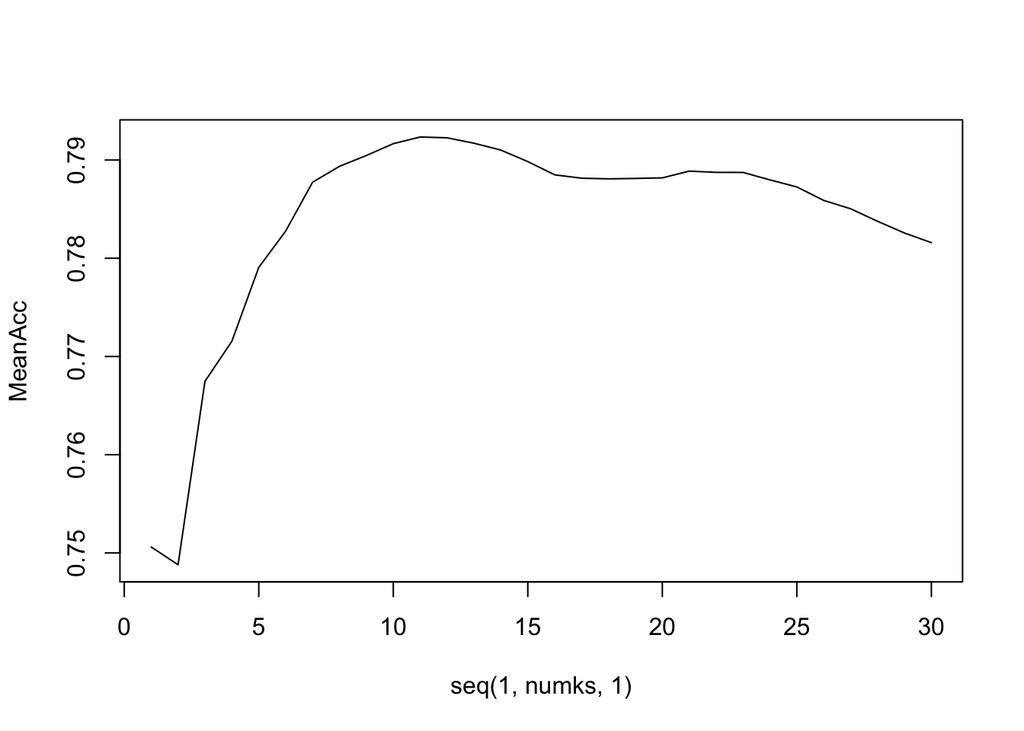

```r
#Now going to loop through more than one k and find the average
iterations = 500
numks = 30

masterAcc = matrix(nrow = iterations, ncol = numks)

for(j in 1:iterations)
{
accs = data.frame(accuracy = numeric(30), k = numeric(30))
trainIndices = sample(1:dim(beersALEIPA)[1], round(splitPerc * dim(beersALEIPA)[1]))
train = beersALEIPA[trainIndices,]
test = beersALEIPA[-trainIndices,]
for(i in 1:numks)
{
  classifications = knn(train[, c(2,3)], test[, c(2,3)], train$Type, prob = TRUE, k = i)
  table(classifications, test$Type)
  CM = confusionMatrix(table(classifications,test$Type))
  masterAcc[j,i] = CM$overall[1]
}

}

MeanAcc = colMeans(masterAcc)

plot(seq(1,numks,1),MeanAcc, type = "l")
```

## Part 9: Supplemental and Bonus information

As a business we would like to see in what areas its best to improve on. As per that note, we decided to give more supplemental information that can help drive sales in some regard.

The below illustrates which region in the US that we see the most IPA beers brewed. It would be best to see this visually, therefore we created a heat map that indicates which regions IPA beer thrive. As per part 8, there were more Ale beers then there were IPA’s. I believe IPAs are still not as popular as Ale’s because of its higher ABV and bitterness. IPA beers provide more bang for the buck and it should definitely be looked into where they tend to thrive and which areas it can improve. The output below should tell us indirectly which area drinks more IPA’s.

```r
#Re-initalize the IPA and Ale beers data frame with state
IPABeers = beersAndBrew %>% select(Beer_Name, ABV, IBU, Style, State) %>% filter(str_detect(Style, "IPA"))
AleBeers = beersAndBrew %>% select(Beer_Name, ABV, IBU, Style, State) %>% filter(str_detect(Style, "Ale"))

#replace all white spaces in states otherwise it will not run properly
IPABeers$State =  str_replace(IPABeers$State, " ", "")

#need to convert abbreviation for state to name
library(openintro)
```

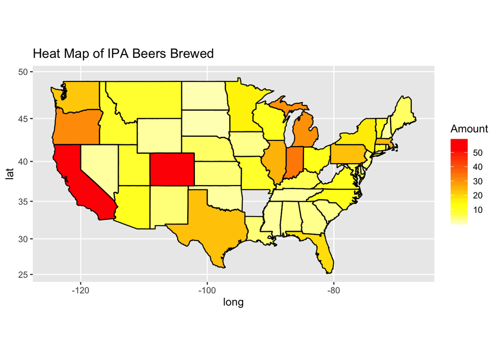

```r
#Load above library to use function abbr2state and create new column for state name
IPABeers$State_Name = abbr2state(IPABeers$State)
#make lowercase for state names as map package will not work
IPABeers$State_Name = tolower(IPABeers$State_Name)

#Count IPA Beers by state
NumberStates = count(IPABeers, State)

#Create state data frame for United States map
states = map_data("state")
map.df = merge(states, IPABeers, by.x = "region", by.y = "State_Name", all.x = T)
map.df = merge(NumberStates, map.df, by = "State")
map.df = map.df[order(map.df$order),]
colnames(map.df)[2] = "Amount"

#Create heat map on US states
map.df %>% ggplot(aes(x = long, y = lat, group = group)) + geom_polygon(aes(fill = Amount)) + geom_path() +
  scale_fill_gradientn(colours = rev(heat.colors(10)), na.value = "grey90") + coord_map() + ggtitle("Heat Map of IPA Beers Brewed")
```